# EDA buscas

O objeto principal da análise são as buscas e a navegação depois da busca. Criamos esses dados a partir dos dados originais da wikimedia em `/data/search_data.csv`.

Aqui, exploramos esses dados.

```r
library(tidyverse)
library(here)
library(lubridate)
theme_set(theme_bw())
```

```r
buscas = read_csv(here::here("data/search_data.csv"))
```

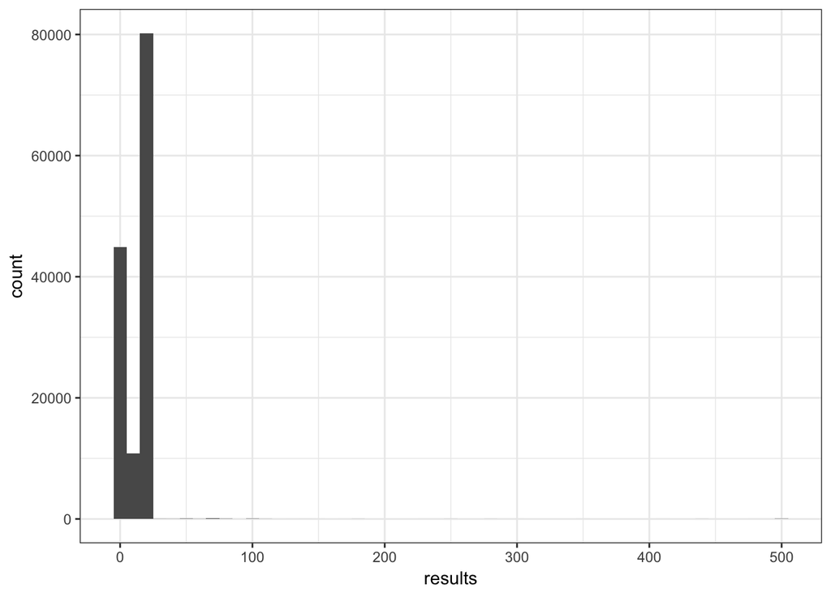

```r
buscas %>%
    ggplot(aes(x = results)) +
    geom_histogram(binwidth = 10)
```

# 1 - What is our daily overall clickthrough rate? How does it vary between the groups?

## Clickthrough = pesquisas que tiveram cliques / pesquisas

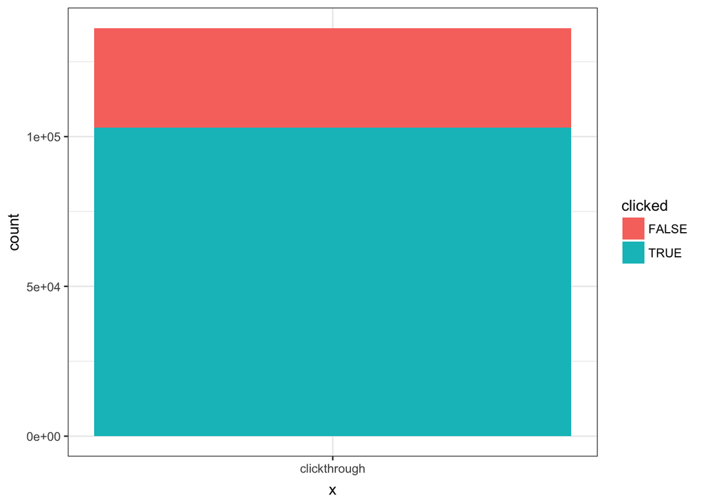

```r
buscas %>%
    mutate(clicked = (is.na(first_click))) %>%
    ggplot(aes(x = "clickthrough")) +
    geom_bar(aes(fill = clicked))
```

Boa parte das sessoes de busca tiveram cliques

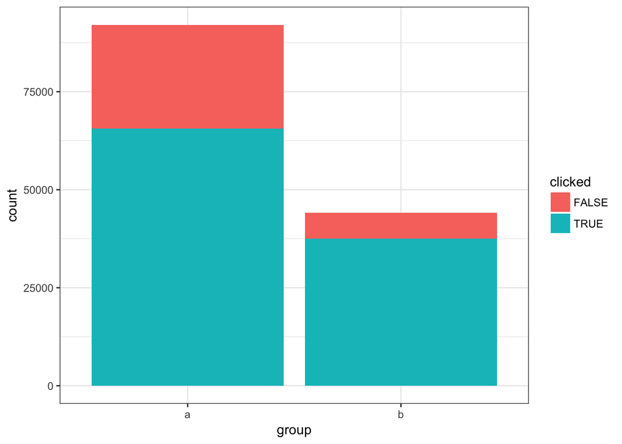

```r
buscas %>%
    mutate(clicked = (is.na(first_click))) %>%
    ggplot(aes(x = group)) +
    geom_bar(aes(fill = clicked))
```

Podemos observcar que há uma pequena diferença nas porporcoes de buscas com cliques

```r
buscas %>%
     mutate(clicked = (is.na(first_click))) %>%
    summarise(num_clicked  = sum(clicked) / nrow((buscas)))
```

| num_clicked |
| --- |
| 0.7563457 |

```r
b <- buscas %>%
    filter(group == 'b')

b %>%
    mutate(clicked = (is.na(first_click))) %>%
    summarise(num_clicked  = sum(clicked) / nrow((b)))
```

| num_clicked |
| --- |
| 0.848454 |

```r
a <- buscas %>%
    filter(group == 'a')

a %>%
    mutate(clicked = (is.na(first_click))) %>%
    summarise(num_clicked  = sum(clicked) / nrow((a)))
```

| num_clicked |
| --- |
| 0.7121426 |

### Pode se observar que a proporção de buscas com clique é de 75%, porém o grupo b tem 85% e o grupo a 71%

# 2 - Which results do people tend to try first? How does it change day-to-day?

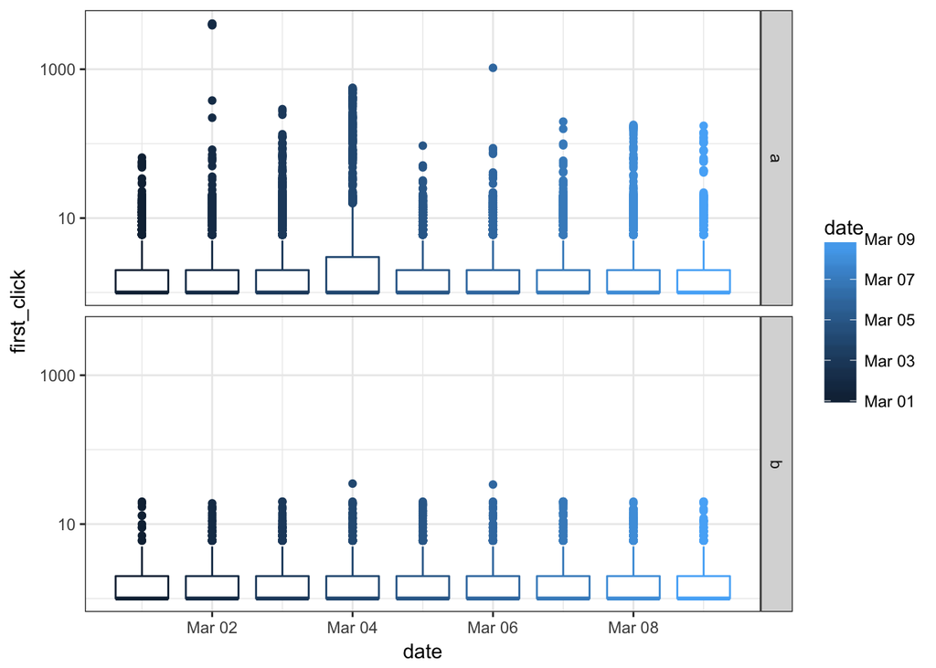

```r
buscas %>%
    filter(!is.na(first_click)) %>%
    mutate(date = round_date(session_start_date, unit = "day")) %>%
    ggplot(aes(x=date, y=first_click, col = date, group=date)) +
    geom_boxplot() +
    scale_y_log10() +
      facet_grid(group ~ .)
```

Podemos observcar que as medianas são iguais nos dias, porém a distribuicao dos grupos se diferencia no que se remete ao percentis maiores

```r
a_not_na <- buscas %>%
        filter(group == 'a') %>%

    filter(!is.na(first_click)) %>%
    mutate(date = round_date(session_start_date, unit = "day"))

first_a <- a_not_na$first_click

quantile(first_a, c(.50, .75, .95, .99))
```

```
## 50% 75% 95% 99%
##   1   2  10  29
```

```r
b_not_na <- buscas %>%
        filter(group == 'b') %>%

    filter(!is.na(first_click)) %>%
    mutate(date = round_date(session_start_date, unit = "day"))

first_b <- b_not_na$first_click

quantile(first_b, c(.50, .75, .95, .99))
```

```
## 50% 75% 95% 99%
##   1   2   6  14
```

### Observa-se que o resultado que as pessoas clicam primeiro é o primeiro resultado, e isso varia muito pouco ao decorrer dos dias, porém o grupo B tem um número mais baixo de piores resultados, como podemos observar nos percentis 95 e 99

# What is our daily overall zero results rate? How does it vary between the groups?

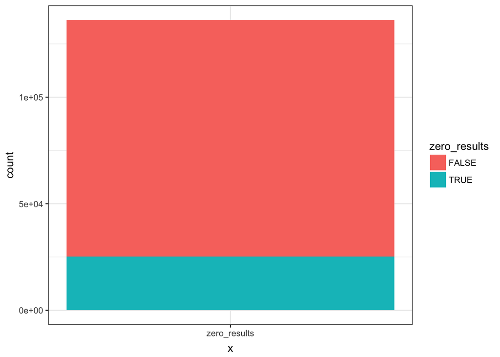

```r
buscas %>%
    mutate(zero_results = (results == 0)) %>%
    ggplot(aes(x = "zero_results")) +
    geom_bar(aes(fill = zero_results))
```

# Observa-se uma taxa por volta de 20% de buscas sem resultado

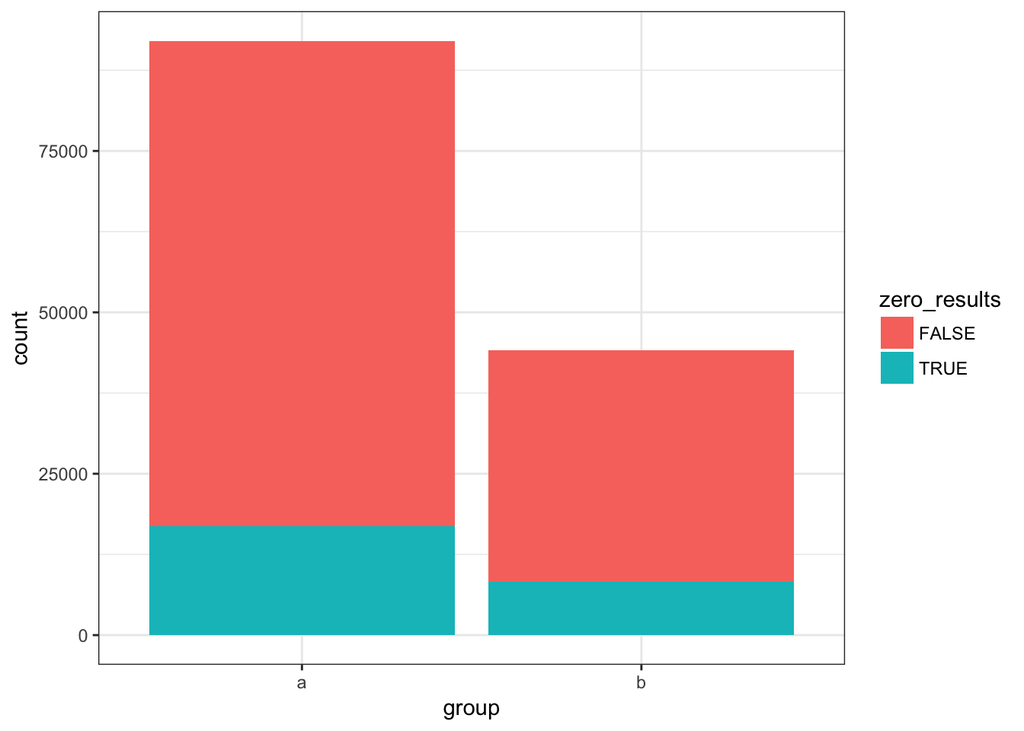

```r
buscas %>%
    mutate(zero_results = (results == 0)) %>%
    ggplot(aes(x = group)) +
    geom_bar(aes(fill = zero_results))
```

A proporção parece ser mantida quando observamos cada grupo

```r
buscas %>%
    mutate(zero_results = (results == 0)) %>%
    summarise(num_clicked  = sum(zero_results) / nrow((buscas)))
```

| num_clicked |
| --- |
| 0.18444 |

```r
a %>%
     mutate(zero_results = (results == 0)) %>%
    summarise(num_clicked  = sum(zero_results) / nrow((a)))
```

| num_clicked |
| --- |
| 0.1836056 |

```r
b %>%
     mutate(zero_results = (results == 0)) %>%
    summarise(num_clicked  = sum(zero_results) / nrow((b)))
```

| num_clicked |
| --- |
| 0.1861786 |

### Pode-se observar que a proporção de pesquisas que geram 0 resultados se mantem entre os grupos